# SpaDES 4 Dummies

Ceres

November 27, 2017

## a VERY simple example of SpaDES awesomeness

This guide will take you through how to start your own model using SpaDES. It assumes you have already installed SpaDES and that it is working in your machine. If you haven’t done this yet, please have a look at [this gist](https://gist.github.com/tati-micheletti/1de7505cdd387fe997f127f13eeb4393) to bypass known issues.

### The example

Let’s imagine we wnat to understant whether the abundance of a species is statitically related with temperature. Both the abundance data and the temperature data are being constanty updated. Also, we want to have the possibility of analysing the relationship between the two iteratively, without needing to constantly change our script to account for the new data inputs. In this example the abundance and temperature data are being updated by a simulation model.

### Before…

If we use R to develop our species abundance and temperature simulation models in the ‘conventional way’, we’ll probably have a script were everything happens - the simulations and data analysis. At most, we would have a main script that sources others that contain useful functions, or are doing the simulations and data treatment/analysis separately. If you already use R like this, you’ll find that the SpaDES way of thinking is similar. So why use it? Because it makes changing, adapting and sharing your code - or modules - much easier.

Still don’t believe me? Okay, let’s solve our problem using the conventional way:

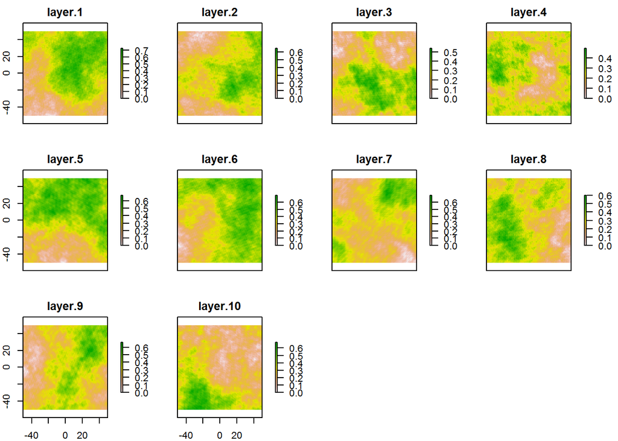

```r
suppressMessages(library(raster))

## Template raster
r <- raster(nrows = 100, ncols = 100, xmn = -50, xmx = 50, ymn = -50, ymx = 50)

## SPECIES ABUNDANCE "SIMULATIONS"
## Our VERY simple "simulation" model merely generates rasters that follows a Gaussian distribution
abundance_model <- function(r, Time) {
  abund_outputs <- list()
  for(t in 1:Time) {
    abund_outputs[[t]] <- SpaDES.tools::gaussMap(r, scale = 100, var = 0.03)
  }
  return(abund_outputs)
}

## Lenght of the simulation (or simply the number of model iterations)
Time <- 10

## Run the model nad plot results
abundance <- abundance_model(r = r, Time = Time)
plot(stack(abundance))
```

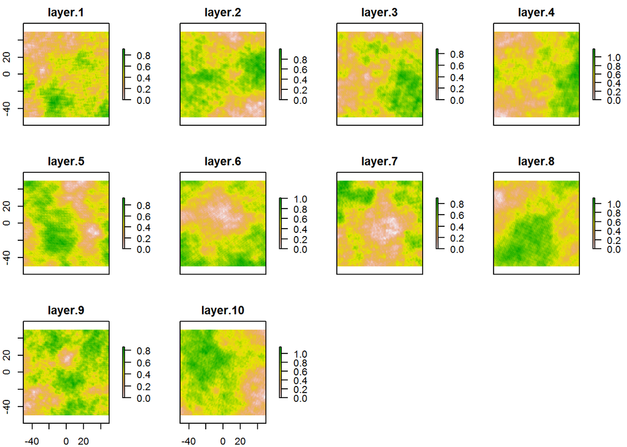

```r
## TEMPERATURE "SIMULATIONS"
## The temperature simulation model will be almost the same as the vegetation one - remember this is a dummy example ;)
r <- raster(nrows = 100, ncols = 100, xmn = -50, xmx = 50, ymn = -50, ymx = 50)
temp_model <- function(r, Time) {
  temp_outputs <- list()
  for(t in 1:Time) {
    temp_outputs[[t]] <- SpaDES.tools::gaussMap(r, scale = 100, var = 0.1)
  }
  return(temp_outputs)
}

## Lenght of the simulation (or simply the number of model iterations)
Time <- 10

## Run the model
temperature <- temp_model(r = r, Time = Time)
plot(stack(temperature))
```

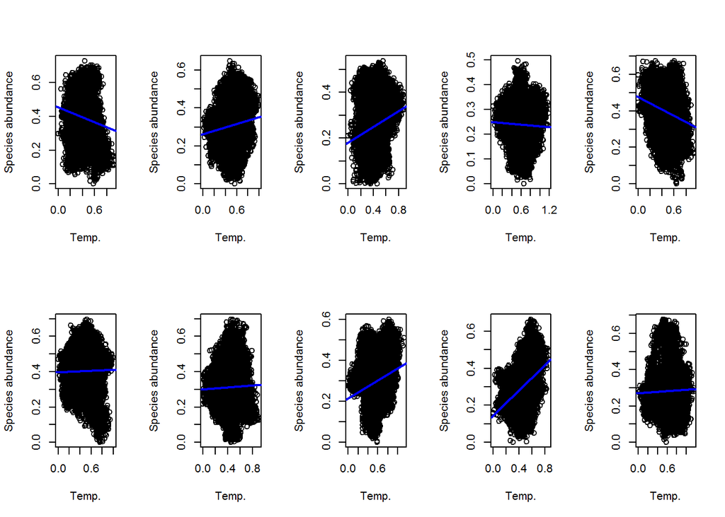

```r
## DATA ANALYSIS
stats_analysis <- function(Data){
  lm1 <- lm(abund ~ temp, data = Data)
  plot(Data$abund ~ Data$temp, xlab = "Temp.", ylab = "Species abundance")
  abline(a = lm1$coefficients["(Intercept)"], b = lm1$coefficients["temp"], lwd = 2, col = "blue")
}

par_sets <- par(mfrow = c(2, 5))
for(t in 1:Time){
  outputdata <- data.frame(abund = abundance[[t]][], temp = temperature[[t]][])
  stats_analysis(Data = outputdata)
}
```

```r
par(par_sets)
```